# Data Analysis - EAMT Statistical Consulting

### Plotting the regressors’ effects on keystrokes

```r
# extract fixed effects table
coefs <- summary(reduced_model_noDiff)$coefficients$cond
df <- as.data.frame(coefs)

# add term names
df$term <- rownames(df)

# rename columns for convenience
df <- df %>%
  rename(
    estimate = Estimate,
    std.error = `Std. Error`,
    p.value = `Pr(>|z|)`
  )

# get confidence intervals
ci <- confint(reduced_model_noDiff, method = "Wald")

# keep only fixed effects
ci <- as.data.frame(ci)
ci$term <- rownames(ci)

df <- df %>%
  left_join(ci, by = "term") %>%
  rename(conf.low = `2.5 %`, conf.high = `97.5 %`)

# remove intercept
df <- df %>%
  filter(term != "(Intercept)")

# relabel terms
df <- df %>%
  mutate(
    term = recode(term,
                  "condition2" = "H-QE",
                  "condition3" = "H-APE",
                  "condition4" = "S-APE",
                  "domainnews" = "Domain: News",
                  "scale(num_characters)" = "Text length",
                  "scale(num_minor)" = "Minor errors",
                  "scale(num_major)" = "Major errors",
                  "scale(MT_Quality)" = "MT quality"
    ),
    significance = ifelse(p.value < 0.05, "Significant", "Not significant")
  )

df <- df %>%
  mutate(significant_flag = p.value < 0.05) %>%
  arrange(desc(significant_flag), desc(abs(estimate))) %>%
  mutate(term = factor(term, levels = rev(term)))
```

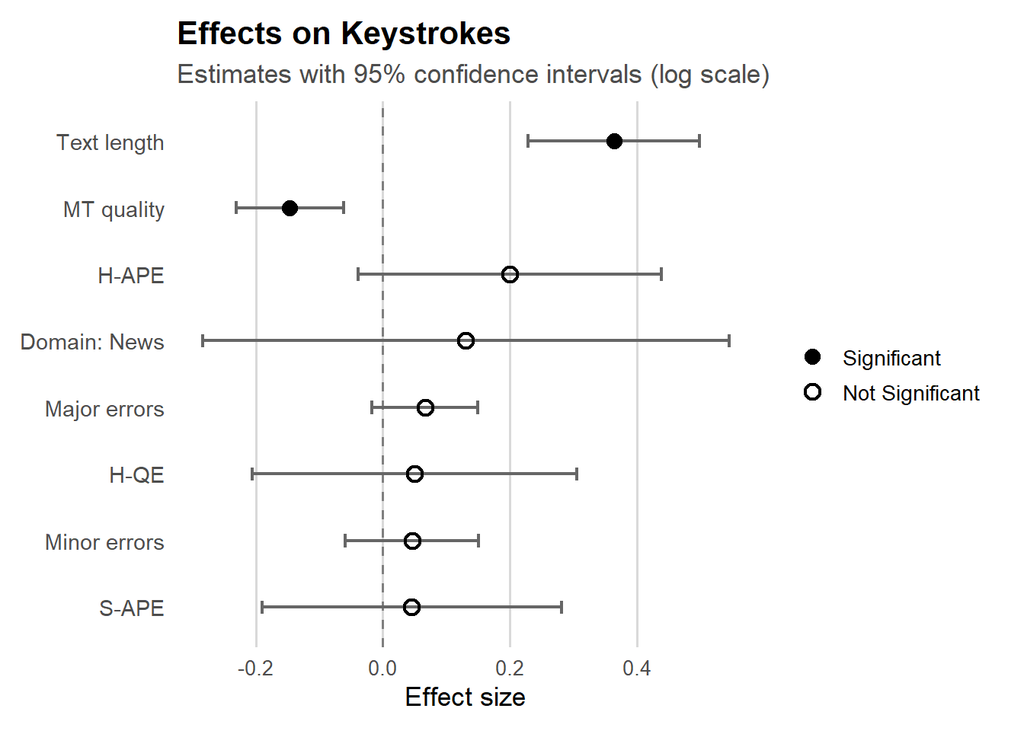

```r
p <- ggplot(df, aes(x = estimate, y = term)) +
  geom_vline(xintercept = 0, linetype = "dashed", linewidth = 0.6, color = "gray50") +

  geom_errorbarh(aes(xmin = conf.low, xmax = conf.high),
                 height = 0.2, linewidth = 0.8, color = "gray40") +

  geom_point(aes(shape = as.factor(!significant_flag)),
             size = 3, stroke = 1.1, color = "black") +

  scale_shape_manual(
    name = NULL,
    values = c(16, 1),
    labels = c("Significant", "Not Significant")
  ) +

  labs(
    title = "Effects on Keystrokes",
    subtitle = "Estimates with 95% confidence intervals (log scale)",
    x = "Effect size",
    y = NULL
  ) +

  theme_minimal(base_size = 13) +
  theme(
    plot.title = element_text(face = "bold"),
    plot.subtitle = element_text(color = "gray30"),
    axis.text.y = element_text(size = 11),
    axis.text.x = element_text(size = 10),
    panel.grid.major.y = element_blank(),
    panel.grid.minor = element_blank(),
    panel.grid.major.x = element_line(color = "gray85"),
    plot.margin = margin(10, 15, 10, 10),
    legend.position = "right"
  )

p
```

### Random Intercepts plots

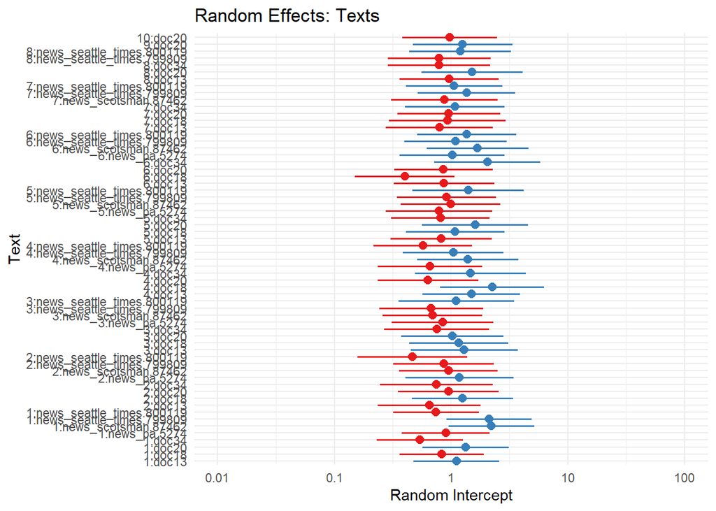

```r
sjPlot::plot_model(reduced_model_noDiff, type = "re", grid = FALSE)[[2]]+
  theme_minimal()+
  labs(x = "Text", y= "Random Intercept", title = "Random Effects: Texts")
```

## Comparing final model Vs other models

```r
# Defining main formula
main_formula <- keystrokes ~ condition + domain + scale(num_characters) +
  scale(num_minor) + scale(num_major) + scale(MT_Quality) +
  (1 | PET) + (1 | text_name / Sent_id)

# Current Tweedie Model
mod_tweedie <- glmmTMB(main_formula,
                       family = tweedie(link = "log"),
                       data = data)


# Zero-Inflated Negative Binomial
# (Assumes some zeros come from a separate always-zero process)
mod_zinb <- glmmTMB(main_formula,
                    ziformula = ~1,
                    family = nbinom2,
                    data = data)

# 3. Hurdle Model (Truncated Negative Binomial)
# (Assumes a process: 0 vs >0, then counts for the rest)
mod_hurdle <- glmmTMB(main_formula,
                      ziformula = ~.,
                      family = truncated_nbinom2,
                      data = data)
```

```r
comparison <- compare_performance(mod_tweedie, mod_zinb, mod_hurdle, metrics = "common")
```

```
## Random effect variances not available. Returned R2 does not account for random effects.
```

```r
print(comparison)
```

```
## # Comparison of Model Performance Indices
##
## Name        |   Model |  AIC (weights) |  BIC (weights) | R2 (cond.)
## --------------------------------------------------------------------
## mod_tweedie | glmmTMB | 4484.8 (0.225) | 4543.7 (>.999) |      0.634
## mod_zinb    | glmmTMB | 4537.3 (<.001) | 4596.2 (<.001) |      0.966
## mod_hurdle  | glmmTMB | 4482.4 (0.775) | 4587.5 (<.001) |
##
## Name        | R2 (marg.) |   RMSE |   ICC
## -----------------------------------------
## mod_tweedie |      0.191 | 31.539 | 0.548
## mod_zinb    |      0.241 | 35.284 | 0.956
## mod_hurdle  |      0.263 | 34.485 |
```

```r
# The 'rho' (power parameter)
glmmTMB::family_params(mod_tweedie)
```

```
## Tweedie power
##      1.396782
```

Even though the Hurdle model has a slightly lower AIC, We would argue for the Tweedie model for three reasons: 1) The BIC weight for the Tweedie model is >.999. This is a massive statistical signal that the Tweedie model is the most parsimonious. 2) The Tweedie model has the lowest RMSE (31.539). This means its actual predictions are closer to actual data points than the other two models. 3) In the Tweedie model, the Itra Class Correlation (ICC) is 0.548, while in the ZI model, it’s 0.956, which is high and might suggests that the model is struggling to separate the random effects from the zero-inflation logic.